# Risk Factor Analysis

## Outcome Variable

**Outcome Variable:** haz

## Predictor Variables

**Intervention Variable:** trth2o

**Adjustment Set:**

- arm
- sex
- W_mage
- meducyrs
- feducyrs
- hhwealth_quart
- hfoodsec
- W_mhtcm
- W_mwtkg
- W_mbmi
- W_nrooms
- W_nhh
- W_nchldlt5
- brthmon
- cleanck
- impfloor
- impsan
- safeh20
- delta_meducyrs
- delta_feducyrs
- delta_hhwealth_quart
- delta_hfoodsec
- delta_W_mhtcm
- delta_W_mwtkg
- delta_W_mbmi
- delta_W_nrooms
- delta_W_nhh
- delta_W_nchldlt5
- delta_brthmon
- delta_cleanck
- delta_impfloor
- delta_impsan
- delta_safeh20

## Stratifying Variables

The analysis was stratified on these variable(s):

- agecat
- studyid
- country

## Data Summary

| agecat | studyid | country | trth2o | n_cell | n |
| --- | --- | --- | --- | --- | --- |
| Birth | ki0047075b-MAL-ED | BANGLADESH | 1 | 117 | 119 |
| Birth | ki0047075b-MAL-ED | BANGLADESH | 0 | 2 | 119 |
| Birth | ki0047075b-MAL-ED | BRAZIL | 1 | 4 | 22 |
| Birth | ki0047075b-MAL-ED | BRAZIL | 0 | 18 | 22 |
| Birth | ki0047075b-MAL-ED | INDIA | 1 | 0 | 2 |
| Birth | ki0047075b-MAL-ED | INDIA | 0 | 2 | 2 |
| Birth | ki0047075b-MAL-ED | NEPAL | 1 | 7 | 9 |
| Birth | ki0047075b-MAL-ED | NEPAL | 0 | 2 | 9 |
| Birth | ki0047075b-MAL-ED | PERU | 1 | 28 | 36 |
| Birth | ki0047075b-MAL-ED | PERU | 0 | 8 | 36 |
| Birth | ki0047075b-MAL-ED | SOUTH AFRICA | 1 | 1 | 5 |
| Birth | ki0047075b-MAL-ED | SOUTH AFRICA | 0 | 4 | 5 |
| Birth | ki0047075b-MAL-ED | TANZANIA, UNITED REPUBLIC OF | 1 | 4 | 22 |
| Birth | ki0047075b-MAL-ED | TANZANIA, UNITED REPUBLIC OF | 0 | 18 | 22 |
| Birth | ki1000108-CMC-V-BCS-2002 | INDIA | 1 | 26 | 26 |
| Birth | ki1000108-CMC-V-BCS-2002 | INDIA | 0 | 0 | 26 |
| Birth | ki1000108-IRC | INDIA | 1 | 120 | 120 |
| Birth | ki1000108-IRC | INDIA | 0 | 0 | 120 |
| Birth | ki1017093b-PROVIDE | BANGLADESH | 1 | 12 | 539 |
| Birth | ki1017093b-PROVIDE | BANGLADESH | 0 | 527 | 539 |
| Birth | ki1017093c-NIH-Crypto | BANGLADESH | 1 | 409 | 732 |
| Birth | ki1017093c-NIH-Crypto | BANGLADESH | 0 | 323 | 732 |
| Birth | ki1113344-GMS-Nepal | NEPAL | 1 | 1 | 4 |
| Birth | ki1113344-GMS-Nepal | NEPAL | 0 | 3 | 4 |
| 6 months | ki0047075b-MAL-ED | BANGLADESH | 1 | 132 | 134 |
| 6 months | ki0047075b-MAL-ED | BANGLADESH | 0 | 2 | 134 |
| 6 months | ki0047075b-MAL-ED | BRAZIL | 1 | 13 | 103 |
| 6 months | ki0047075b-MAL-ED | BRAZIL | 0 | 90 | 103 |
| 6 months | ki0047075b-MAL-ED | INDIA | 1 | 4 | 9 |
| 6 months | ki0047075b-MAL-ED | INDIA | 0 | 5 | 9 |
| 6 months | ki0047075b-MAL-ED | NEPAL | 1 | 69 | 83 |
| 6 months | ki0047075b-MAL-ED | NEPAL | 0 | 14 | 83 |
| 6 months | ki0047075b-MAL-ED | PERU | 1 | 39 | 49 |
| 6 months | ki0047075b-MAL-ED | PERU | 0 | 10 | 49 |
| 6 months | ki0047075b-MAL-ED | SOUTH AFRICA | 1 | 2 | 12 |
| 6 months | ki0047075b-MAL-ED | SOUTH AFRICA | 0 | 10 | 12 |
| 6 months | ki0047075b-MAL-ED | TANZANIA, UNITED REPUBLIC OF | 1 | 6 | 42 |
| 6 months | ki0047075b-MAL-ED | TANZANIA, UNITED REPUBLIC OF | 0 | 36 | 42 |
| 6 months | ki1000108-CMC-V-BCS-2002 | INDIA | 1 | 120 | 120 |
| 6 months | ki1000108-CMC-V-BCS-2002 | INDIA | 0 | 0 | 120 |
| 6 months | ki1000108-IRC | INDIA | 1 | 121 | 121 |
| 6 months | ki1000108-IRC | INDIA | 0 | 0 | 121 |
| 6 months | ki1017093b-PROVIDE | BANGLADESH | 1 | 14 | 604 |
| 6 months | ki1017093b-PROVIDE | BANGLADESH | 0 | 590 | 604 |
| 6 months | ki1017093c-NIH-Crypto | BANGLADESH | 1 | 396 | 715 |
| 6 months | ki1017093c-NIH-Crypto | BANGLADESH | 0 | 319 | 715 |
| 6 months | ki1113344-GMS-Nepal | NEPAL | 1 | 1 | 4 |
| 6 months | ki1113344-GMS-Nepal | NEPAL | 0 | 3 | 4 |
| 24 months | ki0047075b-MAL-ED | BANGLADESH | 1 | 133 | 135 |
| 24 months | ki0047075b-MAL-ED | BANGLADESH | 0 | 2 | 135 |
| 24 months | ki0047075b-MAL-ED | BRAZIL | 1 | 13 | 103 |
| 24 months | ki0047075b-MAL-ED | BRAZIL | 0 | 90 | 103 |
| 24 months | ki0047075b-MAL-ED | INDIA | 1 | 4 | 9 |
| 24 months | ki0047075b-MAL-ED | INDIA | 0 | 5 | 9 |
| 24 months | ki0047075b-MAL-ED | NEPAL | 1 | 69 | 83 |
| 24 months | ki0047075b-MAL-ED | NEPAL | 0 | 14 | 83 |
| 24 months | ki0047075b-MAL-ED | PERU | 1 | 39 | 49 |
| 24 months | ki0047075b-MAL-ED | PERU | 0 | 10 | 49 |
| 24 months | ki0047075b-MAL-ED | SOUTH AFRICA | 1 | 2 | 11 |
| 24 months | ki0047075b-MAL-ED | SOUTH AFRICA | 0 | 9 | 11 |
| 24 months | ki0047075b-MAL-ED | TANZANIA, UNITED REPUBLIC OF | 1 | 6 | 43 |
| 24 months | ki0047075b-MAL-ED | TANZANIA, UNITED REPUBLIC OF | 0 | 37 | 43 |
| 24 months | ki1000108-CMC-V-BCS-2002 | INDIA | 1 | 119 | 119 |
| 24 months | ki1000108-CMC-V-BCS-2002 | INDIA | 0 | 0 | 119 |
| 24 months | ki1000108-IRC | INDIA | 1 | 121 | 121 |
| 24 months | ki1000108-IRC | INDIA | 0 | 0 | 121 |
| 24 months | ki1017093b-PROVIDE | BANGLADESH | 1 | 14 | 578 |
| 24 months | ki1017093b-PROVIDE | BANGLADESH | 0 | 564 | 578 |
| 24 months | ki1017093c-NIH-Crypto | BANGLADESH | 1 | 242 | 514 |
| 24 months | ki1017093c-NIH-Crypto | BANGLADESH | 0 | 272 | 514 |
| 24 months | ki1113344-GMS-Nepal | NEPAL | 1 | 1 | 4 |
| 24 months | ki1113344-GMS-Nepal | NEPAL | 0 | 3 | 4 |

The following strata were considered:

- agecat: 24 months, studyid: ki0047075b-MAL-ED, country: BANGLADESH
- agecat: 24 months, studyid: ki0047075b-MAL-ED, country: BRAZIL
- agecat: 24 months, studyid: ki0047075b-MAL-ED, country: INDIA
- agecat: 24 months, studyid: ki0047075b-MAL-ED, country: NEPAL
- agecat: 24 months, studyid: ki0047075b-MAL-ED, country: PERU
- agecat: 24 months, studyid: ki0047075b-MAL-ED, country: SOUTH AFRICA
- agecat: 24 months, studyid: ki0047075b-MAL-ED, country: TANZANIA, UNITED REPUBLIC OF
- agecat: 24 months, studyid: ki1000108-CMC-V-BCS-2002, country: INDIA
- agecat: 24 months, studyid: ki1000108-IRC, country: INDIA
- agecat: 24 months, studyid: ki1017093b-PROVIDE, country: BANGLADESH
- agecat: 24 months, studyid: ki1017093c-NIH-Crypto, country: BANGLADESH
- agecat: 24 months, studyid: ki1113344-GMS-Nepal, country: NEPAL
- agecat: 6 months, studyid: ki0047075b-MAL-ED, country: BANGLADESH
- agecat: 6 months, studyid: ki0047075b-MAL-ED, country: BRAZIL
- agecat: 6 months, studyid: ki0047075b-MAL-ED, country: INDIA
- agecat: 6 months, studyid: ki0047075b-MAL-ED, country: NEPAL
- agecat: 6 months, studyid: ki0047075b-MAL-ED, country: PERU
- agecat: 6 months, studyid: ki0047075b-MAL-ED, country: SOUTH AFRICA
- agecat: 6 months, studyid: ki0047075b-MAL-ED, country: TANZANIA, UNITED REPUBLIC OF
- agecat: 6 months, studyid: ki1000108-CMC-V-BCS-2002, country: INDIA
- agecat: 6 months, studyid: ki1000108-IRC, country: INDIA
- agecat: 6 months, studyid: ki1017093b-PROVIDE, country: BANGLADESH
- agecat: 6 months, studyid: ki1017093c-NIH-Crypto, country: BANGLADESH
- agecat: 6 months, studyid: ki1113344-GMS-Nepal, country: NEPAL
- agecat: Birth, studyid: ki0047075b-MAL-ED, country: BANGLADESH
- agecat: Birth, studyid: ki0047075b-MAL-ED, country: BRAZIL
- agecat: Birth, studyid: ki0047075b-MAL-ED, country: INDIA
- agecat: Birth, studyid: ki0047075b-MAL-ED, country: NEPAL
- agecat: Birth, studyid: ki0047075b-MAL-ED, country: PERU
- agecat: Birth, studyid: ki0047075b-MAL-ED, country: SOUTH AFRICA
- agecat: Birth, studyid: ki0047075b-MAL-ED, country: TANZANIA, UNITED REPUBLIC OF
- agecat: Birth, studyid: ki1000108-CMC-V-BCS-2002, country: INDIA
- agecat: Birth, studyid: ki1000108-IRC, country: INDIA
- agecat: Birth, studyid: ki1017093b-PROVIDE, country: BANGLADESH
- agecat: Birth, studyid: ki1017093c-NIH-Crypto, country: BANGLADESH
- agecat: Birth, studyid: ki1113344-GMS-Nepal, country: NEPAL

### Dropped Strata

Some strata were dropped due to rare outcomes:

- agecat: Birth, studyid: ki0047075b-MAL-ED, country: BANGLADESH
- agecat: Birth, studyid: ki0047075b-MAL-ED, country: BRAZIL
- agecat: Birth, studyid: ki0047075b-MAL-ED, country: INDIA
- agecat: Birth, studyid: ki0047075b-MAL-ED, country: NEPAL
- agecat: Birth, studyid: ki0047075b-MAL-ED, country: SOUTH AFRICA
- agecat: Birth, studyid: ki0047075b-MAL-ED, country: TANZANIA, UNITED REPUBLIC OF
- agecat: Birth, studyid: ki1000108-CMC-V-BCS-2002, country: INDIA
- agecat: Birth, studyid: ki1000108-IRC, country: INDIA
- agecat: Birth, studyid: ki1113344-GMS-Nepal, country: NEPAL
- agecat: 6 months, studyid: ki0047075b-MAL-ED, country: BANGLADESH
- agecat: 6 months, studyid: ki0047075b-MAL-ED, country: INDIA
- agecat: 6 months, studyid: ki0047075b-MAL-ED, country: SOUTH AFRICA
- agecat: 6 months, studyid: ki1000108-CMC-V-BCS-2002, country: INDIA
- agecat: 6 months, studyid: ki1000108-IRC, country: INDIA
- agecat: 6 months, studyid: ki1113344-GMS-Nepal, country: NEPAL
- agecat: 24 months, studyid: ki0047075b-MAL-ED, country: BANGLADESH
- agecat: 24 months, studyid: ki0047075b-MAL-ED, country: INDIA
- agecat: 24 months, studyid: ki0047075b-MAL-ED, country: SOUTH AFRICA
- agecat: 24 months, studyid: ki1000108-CMC-V-BCS-2002, country: INDIA
- agecat: 24 months, studyid: ki1000108-IRC, country: INDIA
- agecat: 24 months, studyid: ki1113344-GMS-Nepal, country: NEPAL

## Methods Detail

We’re interested in the causal parameters $E[Y_a]$ for all values of $a \in \mathcal{A}$. These parameters represent the mean outcome if, possibly contrary to fact, we intervened to set all units to have $A=a$. Under the randomization and positivity assumptions, these are identified by the statistical parameters $\psi_a=E_W[E_{Y|A,W}(Y|A=a,W)]$. In addition, we’re interested in the mean of $Y$, $E[Y]$ under no intervention (the observed mean). We will estimate these parameters by using SuperLearner to fit the relevant likelihood factors – $E_{Y|A,W}(Y|A=a,W)$ and $p(A=a|W)$, and then updating our likelihood fit using a joint TMLE.

For unadjusted analyses ($W=\{\}$), initial likelihoods were estimated using Lrnr_glm to estimate the simple $E(Y|A)$ and Lrnr_mean to estimate $p(A)$. For adjusted analyses, a small library containing Lrnr_glmnet, Lrnr_xgboost, and Lrnr_mean was used.

Having estimated these parameters, we will then use the delta method to estimate relative risks and attributable risks relative to a prespecified baseline level of $A$.

# Results Detail

## Results Plots

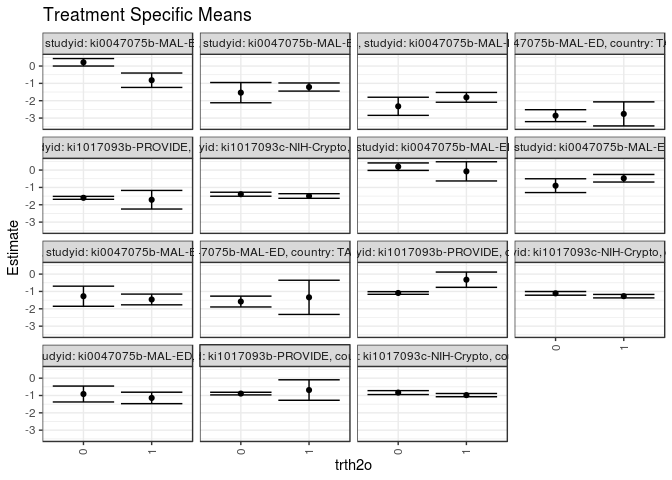

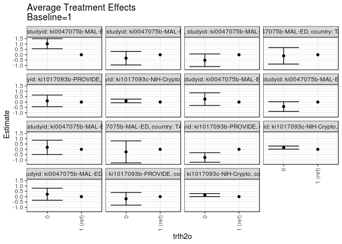

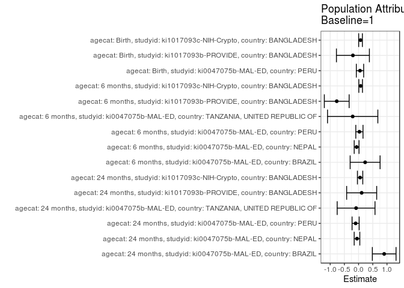

## Results Table

### Parameter: TSM

| agecat | studyid | country | intervention_level | baseline_level | estimate | ci_lower | ci_upper |
| --- | --- | --- | --- | --- | --- | --- | --- |
| Birth | ki0047075b-MAL-ED | PERU | 1 | NA | -1.1403571 | -1.4705172 | -0.8101971 |
| Birth | ki0047075b-MAL-ED | PERU | 0 | NA | -0.9150000 | -1.3733730 | -0.4566270 |
| Birth | ki1017093b-PROVIDE | BANGLADESH | 1 | NA | -0.6856210 | -1.2757326 | -0.0955095 |
| Birth | ki1017093b-PROVIDE | BANGLADESH | 0 | NA | -0.8894143 | -0.9649473 | -0.8138813 |
| Birth | ki1017093c-NIH-Crypto | BANGLADESH | 1 | NA | -0.9784758 | -1.0708888 | -0.8860627 |
| Birth | ki1017093c-NIH-Crypto | BANGLADESH | 0 | NA | -0.8329876 | -0.9459759 | -0.7199993 |
| 6 months | ki0047075b-MAL-ED | BRAZIL | 1 | NA | -0.0750003 | -0.6293463 | 0.4793457 |
| 6 months | ki0047075b-MAL-ED | BRAZIL | 0 | NA | 0.1960576 | -0.0193945 | 0.4115098 |
| 6 months | ki0047075b-MAL-ED | NEPAL | 1 | NA | -0.4726406 | -0.6910882 | -0.2541931 |
| 6 months | ki0047075b-MAL-ED | NEPAL | 0 | NA | -0.9000461 | -1.2974659 | -0.5026263 |
| 6 months | ki0047075b-MAL-ED | PERU | 1 | NA | -1.4624592 | -1.7719436 | -1.1529747 |
| 6 months | ki0047075b-MAL-ED | PERU | 0 | NA | -1.2746231 | -1.8540448 | -0.6952015 |
| 6 months | ki0047075b-MAL-ED | TANZANIA, UNITED REPUBLIC OF | 1 | NA | -1.3394444 | -2.3247416 | -0.3541473 |
| 6 months | ki0047075b-MAL-ED | TANZANIA, UNITED REPUBLIC OF | 0 | NA | -1.5815278 | -1.8930135 | -1.2700421 |
| 6 months | ki1017093b-PROVIDE | BANGLADESH | 1 | NA | -0.3224083 | -0.7622368 | 0.1174201 |
| 6 months | ki1017093b-PROVIDE | BANGLADESH | 0 | NA | -1.0881943 | -1.1637429 | -1.0126456 |
| 6 months | ki1017093c-NIH-Crypto | BANGLADESH | 1 | NA | -1.2718204 | -1.3711936 | -1.1724472 |
| 6 months | ki1017093c-NIH-Crypto | BANGLADESH | 0 | NA | -1.1097844 | -1.2155136 | -1.0040551 |
| 24 months | ki0047075b-MAL-ED | BRAZIL | 1 | NA | -0.8189089 | -1.2331358 | -0.4046821 |
| 24 months | ki0047075b-MAL-ED | BRAZIL | 0 | NA | 0.2143152 | -0.0003991 | 0.4290296 |
| 24 months | ki0047075b-MAL-ED | NEPAL | 1 | NA | -1.2109357 | -1.4466129 | -0.9752584 |
| 24 months | ki0047075b-MAL-ED | NEPAL | 0 | NA | -1.5352087 | -2.1185343 | -0.9518831 |
| 24 months | ki0047075b-MAL-ED | PERU | 1 | NA | -1.8052585 | -2.0873048 | -1.5232123 |
| 24 months | ki0047075b-MAL-ED | PERU | 0 | NA | -2.3217595 | -2.8437669 | -1.7997521 |
| 24 months | ki0047075b-MAL-ED | TANZANIA, UNITED REPUBLIC OF | 1 | NA | -2.7600000 | -3.4536768 | -2.0663232 |
| 24 months | ki0047075b-MAL-ED | TANZANIA, UNITED REPUBLIC OF | 0 | NA | -2.8620270 | -3.2058314 | -2.5182226 |
| 24 months | ki1017093b-PROVIDE | BANGLADESH | 1 | NA | -1.7114000 | -2.2475077 | -1.1752924 |
| 24 months | ki1017093b-PROVIDE | BANGLADESH | 0 | NA | -1.6001955 | -1.6845400 | -1.5158510 |
| 24 months | ki1017093c-NIH-Crypto | BANGLADESH | 1 | NA | -1.4949994 | -1.6268957 | -1.3631031 |
| 24 months | ki1017093c-NIH-Crypto | BANGLADESH | 0 | NA | -1.3931858 | -1.5072947 | -1.2790770 |

### Parameter: E(Y)

| agecat | studyid | country | intervention_level | baseline_level | estimate | ci_lower | ci_upper |
| --- | --- | --- | --- | --- | --- | --- | --- |
| Birth | ki0047075b-MAL-ED | PERU | NA | NA | -1.0902778 | -1.3682718 | -0.8122837 |
| Birth | ki1017093b-PROVIDE | BANGLADESH | NA | NA | -0.8851020 | -0.9601332 | -0.8100709 |
| Birth | ki1017093c-NIH-Crypto | BANGLADESH | NA | NA | -0.9094945 | -0.9809370 | -0.8380521 |
| 6 months | ki0047075b-MAL-ED | BRAZIL | NA | NA | 0.1558900 | -0.0436128 | 0.3553927 |
| 6 months | ki0047075b-MAL-ED | NEPAL | NA | NA | -0.5416867 | -0.7337282 | -0.3496452 |
| 6 months | ki0047075b-MAL-ED | PERU | NA | NA | -1.4335034 | -1.6988926 | -1.1681142 |
| 6 months | ki0047075b-MAL-ED | TANZANIA, UNITED REPUBLIC OF | NA | NA | -1.5469444 | -1.8498756 | -1.2440133 |
| 6 months | ki1017093b-PROVIDE | BANGLADESH | NA | NA | -1.0916915 | -1.1661176 | -1.0172654 |
| 6 months | ki1017093c-NIH-Crypto | BANGLADESH | NA | NA | -1.1986783 | -1.2700937 | -1.1272630 |
| 24 months | ki0047075b-MAL-ED | BRAZIL | NA | NA | 0.0833172 | -0.1220854 | 0.2887197 |
| 24 months | ki0047075b-MAL-ED | NEPAL | NA | NA | -1.2665060 | -1.4788044 | -1.0542077 |
| 24 months | ki0047075b-MAL-ED | PERU | NA | NA | -1.9093878 | -2.1570845 | -1.6616910 |
| 24 months | ki0047075b-MAL-ED | TANZANIA, UNITED REPUBLIC OF | NA | NA | -2.8477907 | -3.1592380 | -2.5363434 |
| 24 months | ki1017093b-PROVIDE | BANGLADESH | NA | NA | -1.6024221 | -1.6857420 | -1.5191023 |
| 24 months | ki1017093c-NIH-Crypto | BANGLADESH | NA | NA | -1.4412646 | -1.5249156 | -1.3576135 |

### Parameter: ATE

| agecat | studyid | country | intervention_level | baseline_level | estimate | ci_lower | ci_upper |
| --- | --- | --- | --- | --- | --- | --- | --- |
| Birth | ki0047075b-MAL-ED | PERU | 1 | 1 | 0.0000000 | 0.0000000 | 0.0000000 |
| Birth | ki0047075b-MAL-ED | PERU | 0 | 1 | 0.2253571 | -0.3395424 | 0.7902567 |
| Birth | ki1017093b-PROVIDE | BANGLADESH | 1 | 1 | 0.0000000 | 0.0000000 | 0.0000000 |
| Birth | ki1017093b-PROVIDE | BANGLADESH | 0 | 1 | -0.2037933 | -0.7989036 | 0.3913170 |
| Birth | ki1017093c-NIH-Crypto | BANGLADESH | 1 | 1 | 0.0000000 | 0.0000000 | 0.0000000 |
| Birth | ki1017093c-NIH-Crypto | BANGLADESH | 0 | 1 | 0.1454882 | 0.0000364 | 0.2909399 |
| 6 months | ki0047075b-MAL-ED | BRAZIL | 1 | 1 | 0.0000000 | 0.0000000 | 0.0000000 |
| 6 months | ki0047075b-MAL-ED | BRAZIL | 0 | 1 | 0.2710579 | -0.3232742 | 0.8653900 |
| 6 months | ki0047075b-MAL-ED | NEPAL | 1 | 1 | 0.0000000 | 0.0000000 | 0.0000000 |
| 6 months | ki0047075b-MAL-ED | NEPAL | 0 | 1 | -0.4274055 | -0.8835478 | 0.0287369 |
| 6 months | ki0047075b-MAL-ED | PERU | 1 | 1 | 0.0000000 | 0.0000000 | 0.0000000 |
| 6 months | ki0047075b-MAL-ED | PERU | 0 | 1 | 0.1878361 | -0.4801251 | 0.8557972 |
| 6 months | ki0047075b-MAL-ED | TANZANIA, UNITED REPUBLIC OF | 1 | 1 | 0.0000000 | 0.0000000 | 0.0000000 |
| 6 months | ki0047075b-MAL-ED | TANZANIA, UNITED REPUBLIC OF | 0 | 1 | -0.2420833 | -1.2754438 | 0.7912771 |
| 6 months | ki1017093b-PROVIDE | BANGLADESH | 1 | 1 | 0.0000000 | 0.0000000 | 0.0000000 |
| 6 months | ki1017093b-PROVIDE | BANGLADESH | 0 | 1 | -0.7657859 | -1.2131173 | -0.3184545 |
| 6 months | ki1017093c-NIH-Crypto | BANGLADESH | 1 | 1 | 0.0000000 | 0.0000000 | 0.0000000 |
| 6 months | ki1017093c-NIH-Crypto | BANGLADESH | 0 | 1 | 0.1620360 | 0.0176135 | 0.3064585 |
| 24 months | ki0047075b-MAL-ED | BRAZIL | 1 | 1 | 0.0000000 | 0.0000000 | 0.0000000 |
| 24 months | ki0047075b-MAL-ED | BRAZIL | 0 | 1 | 1.0332242 | 0.5660892 | 1.5003591 |
| 24 months | ki0047075b-MAL-ED | NEPAL | 1 | 1 | 0.0000000 | 0.0000000 | 0.0000000 |
| 24 months | ki0047075b-MAL-ED | NEPAL | 0 | 1 | -0.3242731 | -0.9544066 | 0.3058605 |
| 24 months | ki0047075b-MAL-ED | PERU | 1 | 1 | 0.0000000 | 0.0000000 | 0.0000000 |
| 24 months | ki0047075b-MAL-ED | PERU | 0 | 1 | -0.5165009 | -1.1091669 | 0.0761650 |
| 24 months | ki0047075b-MAL-ED | TANZANIA, UNITED REPUBLIC OF | 1 | 1 | 0.0000000 | 0.0000000 | 0.0000000 |
| 24 months | ki0047075b-MAL-ED | TANZANIA, UNITED REPUBLIC OF | 0 | 1 | -0.1020270 | -0.8762292 | 0.6721752 |
| 24 months | ki1017093b-PROVIDE | BANGLADESH | 1 | 1 | 0.0000000 | 0.0000000 | 0.0000000 |
| 24 months | ki1017093b-PROVIDE | BANGLADESH | 0 | 1 | 0.1112045 | -0.4313966 | 0.6538057 |
| 24 months | ki1017093c-NIH-Crypto | BANGLADESH | 1 | 1 | 0.0000000 | 0.0000000 | 0.0000000 |
| 24 months | ki1017093c-NIH-Crypto | BANGLADESH | 0 | 1 | 0.1018136 | -0.0724147 | 0.2760419 |

### Parameter: PAR

| agecat | studyid | country | intervention_level | baseline_level | estimate | ci_lower | ci_upper |
| --- | --- | --- | --- | --- | --- | --- | --- |
| Birth | ki0047075b-MAL-ED | PERU | 1 | NA | 0.0500794 | -0.0792342 | 0.1793930 |
| Birth | ki1017093b-PROVIDE | BANGLADESH | 1 | NA | -0.1994810 | -0.7800832 | 0.3811212 |
| Birth | ki1017093c-NIH-Crypto | BANGLADESH | 1 | NA | 0.0689812 | 0.0034664 | 0.1344961 |
| 6 months | ki0047075b-MAL-ED | BRAZIL | 1 | NA | 0.2308903 | -0.2964909 | 0.7582714 |
| 6 months | ki0047075b-MAL-ED | NEPAL | 1 | NA | -0.0690461 | -0.1538334 | 0.0157412 |
| 6 months | ki0047075b-MAL-ED | PERU | 1 | NA | 0.0289558 | -0.0977963 | 0.1557079 |
| 6 months | ki0047075b-MAL-ED | TANZANIA, UNITED REPUBLIC OF | 1 | NA | -0.2075000 | -1.0936170 | 0.6786170 |
| 6 months | ki1017093b-PROVIDE | BANGLADESH | 1 | NA | -0.7692832 | -1.2060984 | -0.3324679 |
| 6 months | ki1017093c-NIH-Crypto | BANGLADESH | 1 | NA | 0.0731421 | 0.0086563 | 0.1376278 |
| 24 months | ki0047075b-MAL-ED | BRAZIL | 1 | NA | 0.9022261 | 0.4850822 | 1.3193699 |
| 24 months | ki0047075b-MAL-ED | NEPAL | 1 | NA | -0.0555704 | -0.1544557 | 0.0433150 |
| 24 months | ki0047075b-MAL-ED | PERU | 1 | NA | -0.1041292 | -0.2291063 | 0.0208478 |
| 24 months | ki0047075b-MAL-ED | TANZANIA, UNITED REPUBLIC OF | 1 | NA | -0.0877907 | -0.7540505 | 0.5784691 |
| 24 months | ki1017093b-PROVIDE | BANGLADESH | 1 | NA | 0.1089779 | -0.4201348 | 0.6380905 |
| 24 months | ki1017093c-NIH-Crypto | BANGLADESH | 1 | NA | 0.0537348 | -0.0403991 | 0.1478688 |